# DATA 599 - Survival Analysis HW7 - Charles Hanks

Due: April 7, 2023

** CHANGE YOUR NAME IN THE TITLE AND COMPLETE THE FOLLOWING: **

# DATASET: pharmacoSmoking-asaur.txt

This dataset, leveraged from *Applied Survival Analysis Using R* contains the following variables:

- id (patient ID number)
- ttr (Time in days until relapse)
- relapse (Indicator of return to smoking)
- grp (Randomly assigned treatment group with levels combination or patchOnly)
- age (Age in years at time of randomization)
- gender (Female or Male)
- race (black, hispanic, white, or other)
- employment (ft=full-time, pt=part-time, or other)
- yearsSmoking (Number of years the patient had been a smoker)
- levelSmoking (heavy or light)
- ageGroup2 (Age group with levels 21-49 or 50+)
- ageGroup4 (Age group with levels 21-34, 35-49, 50-64, or 65+)
- priorAttempts (The number of prior attempts to quit smoking)
- longestNoSmoke (The longest period of time, in days, that the patient has previously gone without smoking)

The time to relapse (ttr) is the time variable of interest, and the relapse variable is the censoring variable. Please read in the dataset and do the following:

## A

We need to do some wrangling. Replace all 0’s in the `ttr` column with 0.00001 (or a similarly tiny #). Also, change the order of the race variable levels to {white, black, hispanic, other}.

```r
ds = read_csv('pharmacoSmoking-asaur.txt')
ds = ds %>% mutate(ttr = ifelse(ttr == 0, 0.0001,ttr)) %>%
       mutate(race = factor(race, levels = c('white', 'black','hispanic','other')))
```

## B

Create separate KM survival curves for the following relationships: - ttr vs. grp - ttr vs. gender - ttr vs. race - ttr vs. levelSmoking - ttr vs. ageGroup4

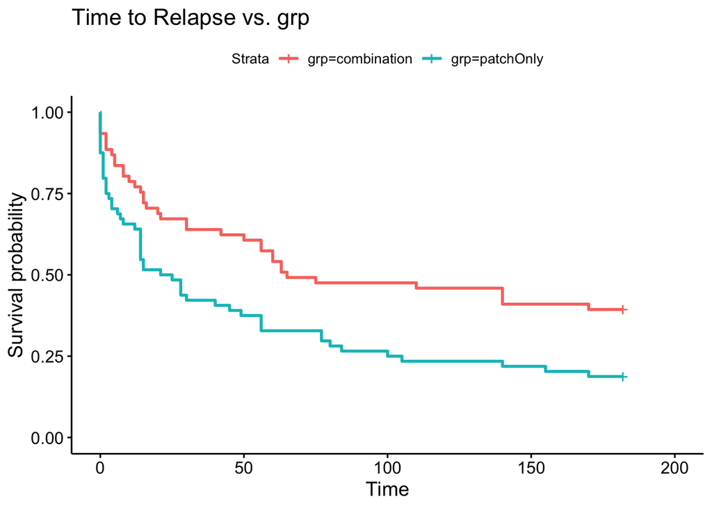

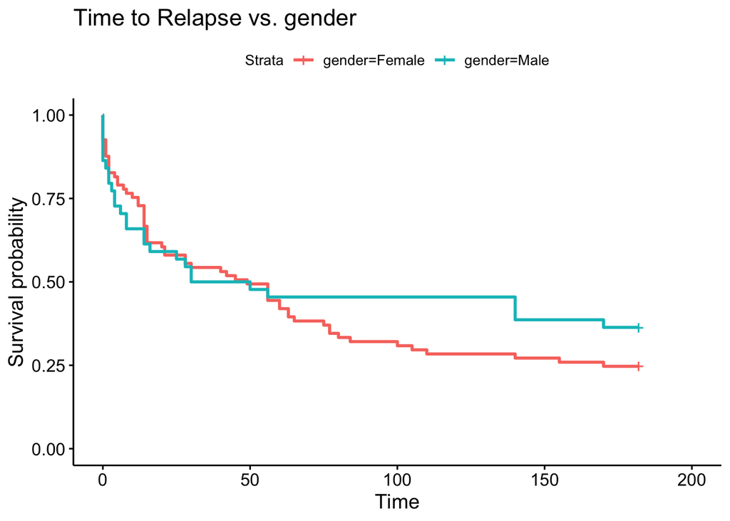

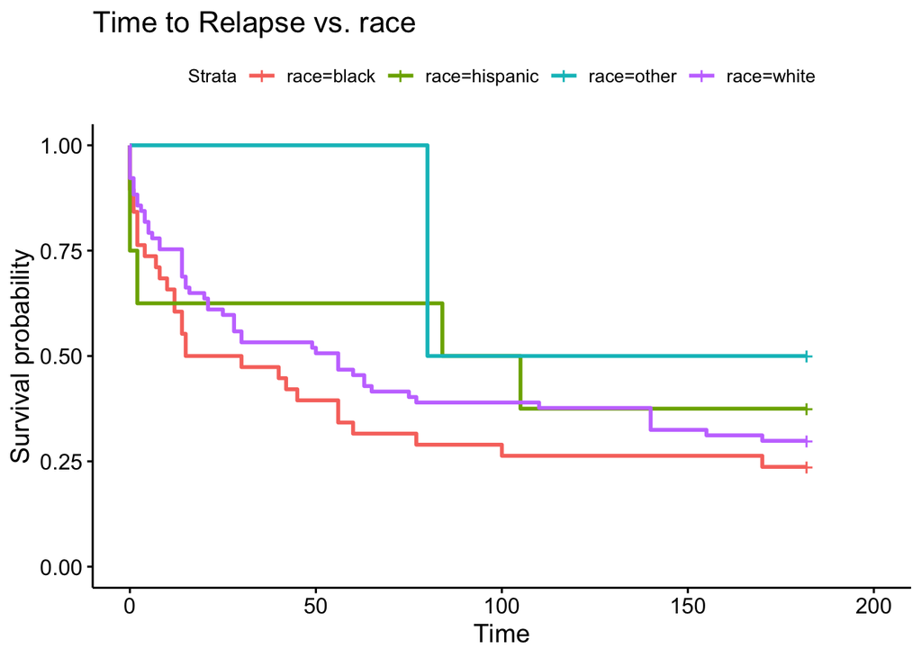

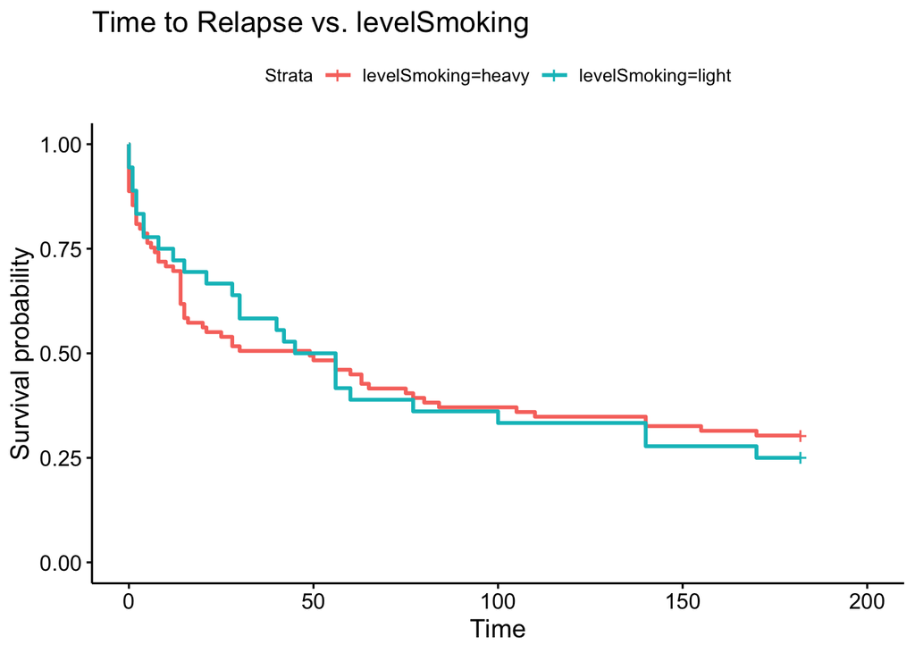

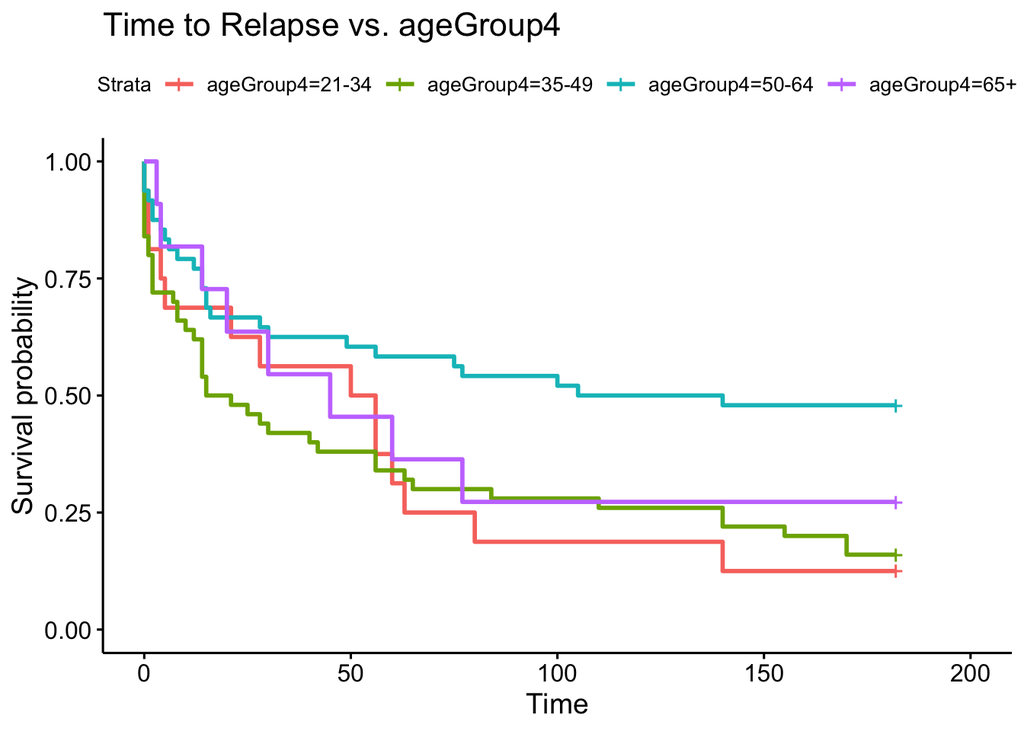

```r
#testing on first variable
#km.grp = survfit(Surv(ds$ttr,ds$relapse) ~ ds$grp)
#ggsurvplot(fit = km.grp, data = ds, risk.table = F, conf.int = T)

#creating list of var names to iterate over
vars = list('grp', 'gender', 'race', 'levelSmoking', 'ageGroup4')

#iterating through list of vars to generate separate km curve for each km table
for(var in vars){
  str = paste0('survfit(Surv(ds$ttr,ds$relapse) ~ ds$', var,')')
  km.fit = eval(parse(text = str))
  print(ggsurvplot(fit = km.fit, data = ds, risk.table = F, conf.int = F) + labs(title = paste('Time to Relapse vs. ', var,sep ='')))
}
```

## C

Create a joint Weibull model with the variables in part A using `survreg`. Name this model `weibullMod`.

```r
weibullMod = survreg(Surv(ttr,relapse)~ grp + gender + race + levelSmoking + ageGroup4, data = ds)
```

## D

Run `broom::tidy(weibullMod)` on the model. Which variables are statistically significant? (Hint: which variables have a p-value < 0.05?)

```r
broom::tidy(weibullMod)
```

```
## # A tibble: 11 × 5
##    term              estimate std.error statistic  p.value
##    <chr>                <dbl>     <dbl>     <dbl>    <dbl>
##  1 (Intercept)         4.60      0.971     4.74   2.18e- 6
##  2 grppatchOnly       -1.57      0.630    -2.49   1.29e- 2
##  3 genderMale          0.135     0.686     0.197  8.44e- 1
##  4 raceblack          -0.652     0.721    -0.903  3.66e- 1
##  5 racehispanic       -0.0757    1.36     -0.0558 9.56e- 1
##  6 raceother           2.21      2.96      0.746  4.56e- 1
##  7 levelSmokinglight   0.439     0.756     0.581  5.61e- 1
##  8 ageGroup435-49      0.0553    0.930     0.0595 9.53e- 1
##  9 ageGroup450-64      2.26      1.04      2.19   2.89e- 2
## 10 ageGroup465+        0.780     1.30      0.600  5.48e- 1
## 11 Log(scale)          1.05      0.0961   11.0    5.85e-28
```

**ANSWER:** The statistically significant variables are grp:pathOnly and ageGroup4:50-64.

## E

Run a Cox proportional hazards model with the same variables in part A using `coxph`. Name this model `coxMod`.

```r
coxMod=coxph(Surv(ttr,relapse)~grp + gender + race + levelSmoking + ageGroup4, data = ds)
```

## F

Run `summary(coxMod)`. What is the interpretation of the grp (i.e. treatment) coefficient? Hint: look at the coefficient in the exp(coef) column. What does it mean to be >1?

```r
summary(coxMod)
```

```
## Call:
## coxph(formula = Surv(ttr, relapse) ~ grp + gender + race + levelSmoking +
##     ageGroup4, data = ds)
##
##   n= 125, number of events= 89
##
##                        coef exp(coef)  se(coef)      z Pr(>|z|)
## grppatchOnly       0.591244  1.806233  0.217808  2.715  0.00664 **
## genderMale        -0.059731  0.942018  0.240374 -0.248  0.80376
## raceblack          0.264031  1.302168  0.253047  1.043  0.29676
## racehispanic      -0.061393  0.940453  0.472713 -0.130  0.89667
## raceother         -0.870664  0.418673  1.033348 -0.843  0.39947
## levelSmokinglight -0.156105  0.855469  0.264244 -0.591  0.55468
## ageGroup435-49    -0.007779  0.992251  0.326050 -0.024  0.98096
## ageGroup450-64    -0.819634  0.440593  0.358890 -2.284  0.02238 *
## ageGroup465+      -0.249212  0.779415  0.453020 -0.550  0.58224
## ---
## Signif. codes:  0 '***' 0.001 '**' 0.01 '*' 0.05 '.' 0.1 ' ' 1
##
##                   exp(coef) exp(-coef) lower .95 upper .95
## grppatchOnly         1.8062     0.5536   1.17862    2.7680
## genderMale           0.9420     1.0616   0.58810    1.5089
## raceblack            1.3022     0.7679   0.79300    2.1383
## racehispanic         0.9405     1.0633   0.37236    2.3753
## raceother            0.4187     2.3885   0.05524    3.1729
## levelSmokinglight    0.8555     1.1689   0.50966    1.4359
## ageGroup435-49       0.9923     1.0078   0.52371    1.8800
## ageGroup450-64       0.4406     2.2697   0.21805    0.8903
## ageGroup465+         0.7794     1.2830   0.32074    1.8940
##
## Concordance= 0.649  (se = 0.033 )
## Likelihood ratio test= 22.22  on 9 df,   p=0.008
## Wald test            = 20.62  on 9 df,   p=0.01
## Score (logrank) test = 21.42  on 9 df,   p=0.01
```

**ANSWER:** Exp(coef) of grp is 1.81. We should interpret this coefficient for grppatchOnly as a hazard ratio, exp(B_1). We can say that the hazard (of relapse) increases by a factor of 1.81 when the treatment for is patch only. In other words, the hazard increases by 81% for patch only compared to the baseline combination treatment.

## G

What is the interpretation of the smoking level coefficient?

**ANSWER:** Exp(coef) of levelSmokinglight is .86. This means that the hazard decreases by 14% when the smoking level of the patient is light compared to baseline heavy smoking level.

## H

We need to check the model diagnostics to verify that this model satisfies assumptions of the Cox PH model. Uncomment and run the following code:

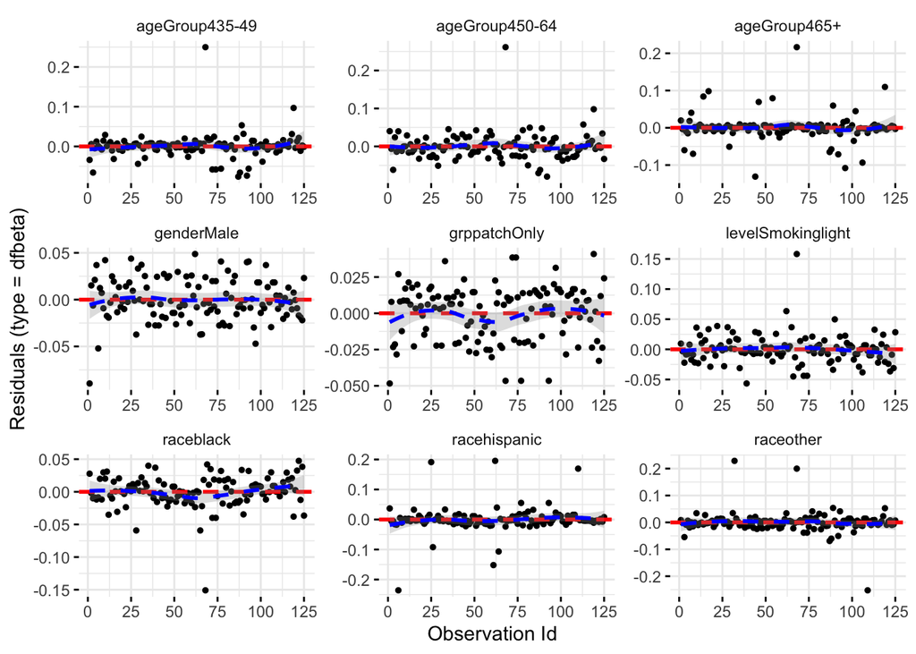

```r
#checking for leverage points or outliers ("influential points"):
ggcoxdiagnostics(coxMod, type = "dfbeta", linear.predictions = FALSE, ggtheme = theme_minimal())
```

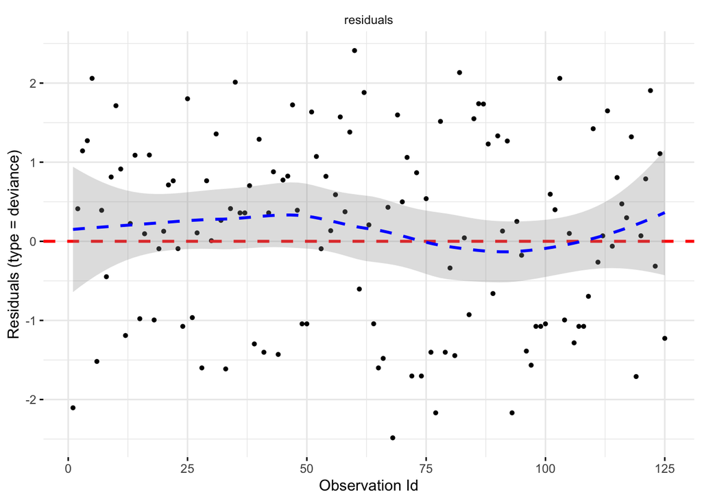

```r
ggcoxdiagnostics(coxMod, type = "deviance",  linear.predictions = FALSE, ggtheme = theme_minimal())
```

Examine the plots. Are there any influential points?

Based on these two plots I would say there are no points of major influence.

## I

Run the following code to check the proportional hazards assumption:

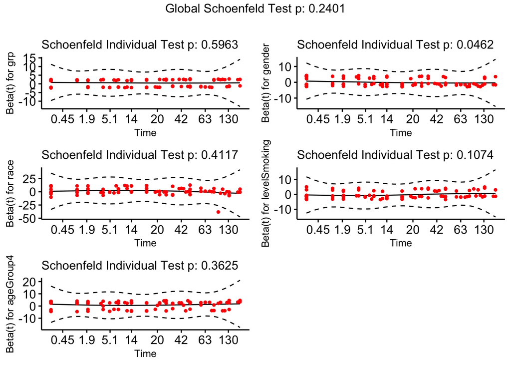

```r
coxZPH=cox.zph(coxMod)
ggcoxzph(coxZPH,font.x=10,font.y=10,font.main=12)
```

Based on the Schoenfeld residuals, is the proportional hazards assumption satisfied?

## J

Using the variable names in the dataset, create a data frame for a 60yo Black male who is a light smoker. One row should correspond to grp=“patchOnly” and the second row should correspond to the combination treatment. (Hint: expand.grid). Name this data frame `newData`.

```r
newData =
  expand.grid(
    grp= c("patchOnly","combination"),
    age= 60,
    gender = "Male",
    race= "black",
    levelSmoking= "light",
    ageGroup4 = "50-64")
```

## K

Uncomment and run the following code to create the survival tables for the cox PH curves:

```r
coxSurvTables=survfit(coxMod, data = ds, newdata = newData, conf.type = "none")
surv_summary(coxSurvTables)
```

```
##        time n.risk n.event n.censor      surv    std.err upper lower strata
## 1    0.0001    125      12        0 0.9252540 0.03319682    NA    NA      1
## 2    1.0000    113       5        0 0.8928304 0.04508319    NA    NA      1
## 3    2.0000    108       6        0 0.8527918 0.06019739    NA    NA      1
## 4    3.0000    102       1        0 0.8460480 0.06280277    NA    NA      1
## 5    4.0000    101       3        0 0.8256546 0.07081424    NA    NA      1
## 6    5.0000     98       2        0 0.8119766 0.07631531    NA    NA      1
## 7    6.0000     96       1        0 0.8051494 0.07908054    NA    NA      1
## 8    7.0000     95       1        0 0.7983282 0.08187153    NA    NA      1
## 9    8.0000     94       3        0 0.7774843 0.09055964    NA    NA      1
## 10  10.0000     91       1        0 0.7704947 0.09353459    NA    NA      1
## 11  12.0000     90       2        0 0.7564274 0.09958965    NA    NA      1
## 12  14.0000     88       7        0 0.7058884 0.12230619    NA    NA      1
## 13  15.0000     81       4        0 0.6759651 0.13649254    NA    NA      1
## 14  16.0000     77       1        0 0.6684214 0.14017439    NA    NA      1
```

[output cut: 64 more lines]

Then use the survfit object and `ggsurvplot` to create survival curves for a 60yo Black male. There should be a curve for each treatment (patchOnly, combination).

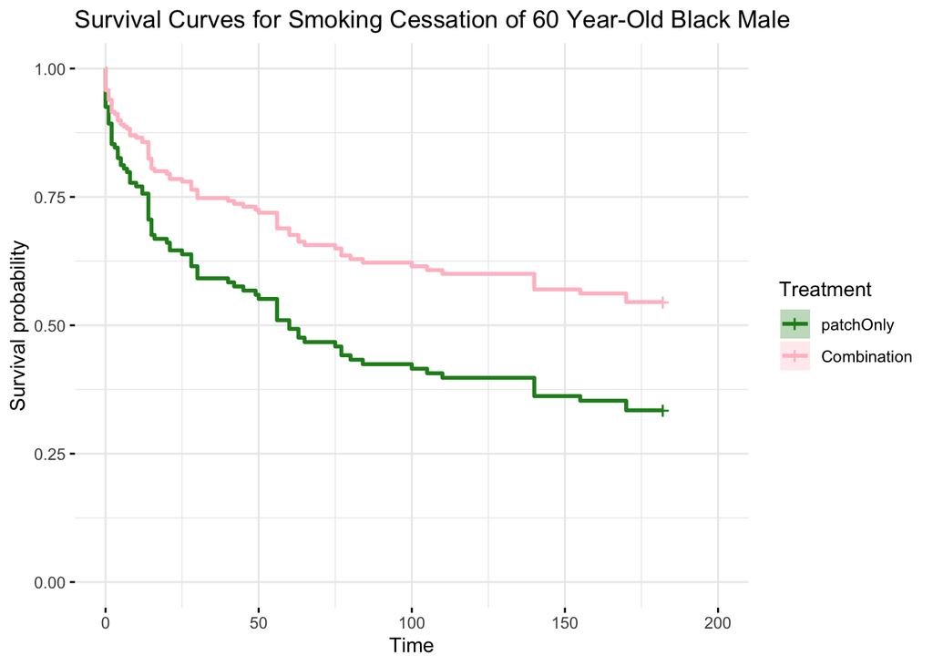

```r
ggsurvplot(fit=coxSurvTables, palette=c("forestgreen","pink"),
ggtheme=theme_minimal(), legend="right", legend.title="Treatment",
legend.labs=c("patchOnly","Combination"), title = "Survival Curves for Smoking Cessation of 60 Year-Old Black Male")
```